# Pan-cancer age-associated molecular changes

## Overview

This script generates manuscript-oriented plots for part 1 from the official derived outputs:

- per-layer counts and direction of age-associated features,
- a multi-omic cancer similarity dendrogram using the layer set selected in `03_prepare_clustering.Rmd`,
- an RNA-seq Hallmark GSEA combined heatmap (currently unused in the main manuscript figure),
- within- versus between-organ-system pairwise distances by molecular layer.

The similarity dendrogram and within- versus between-organ-system comparison both rely on `pancancer_clustering_results.rds`, which contains the layer-inclusion diagnostics, retained-layer similarity matrices, the per-pair overlap floor used during averaging, and the final hierarchical clustering. This script reads those outputs directly without re-deriving them. Not every plot generated here is necessarily included in the published manuscript, and final multi-panel assembly may be performed in Adobe Illustrator.

## Libraries

```r
suppressPackageStartupMessages({
  library(dplyr)
  library(ggplot2)
  library(here)
  library(ape)
  library(ggtree)
  library(pheatmap)
  library(cba)
  library(reactable)
})
```

## Paths

```r
import_file <- here::here(
  "results", "derived", "part1", "01_import_official_results", "part1_imported_results.rds"
)

gsea_file <- here::here(
  "results", "derived", "part1", "02_rnaseq_hallmark_gsea", "rnaseq_hallmark_gsea_results.rds"
)

clustering_file <- here::here(
  "results", "derived", "part1", "03_prepare_clustering", "pancancer_clustering_results.rds"
)

missing_files <- c(import_file, gsea_file, clustering_file)[!file.exists(c(import_file, gsea_file, clustering_file))]
if (length(missing_files) > 0) {
  stop(
    "Missing required inputs. Run the part-1 prep Rmds first:\n",
    paste(missing_files, collapse = "\n")
  )
}

fig_dir <- here::here("results", "figures", "part1")
dir.create(fig_dir, recursive = TRUE, showWarnings = FALSE)
```

## Load official derived results

```r
part1_imported_results <- readRDS(import_file)
rnaseq_hallmark_gsea   <- readRDS(gsea_file)
pancancer_clustering   <- readRDS(clustering_file)
```

## Per-layer age-associated feature counts

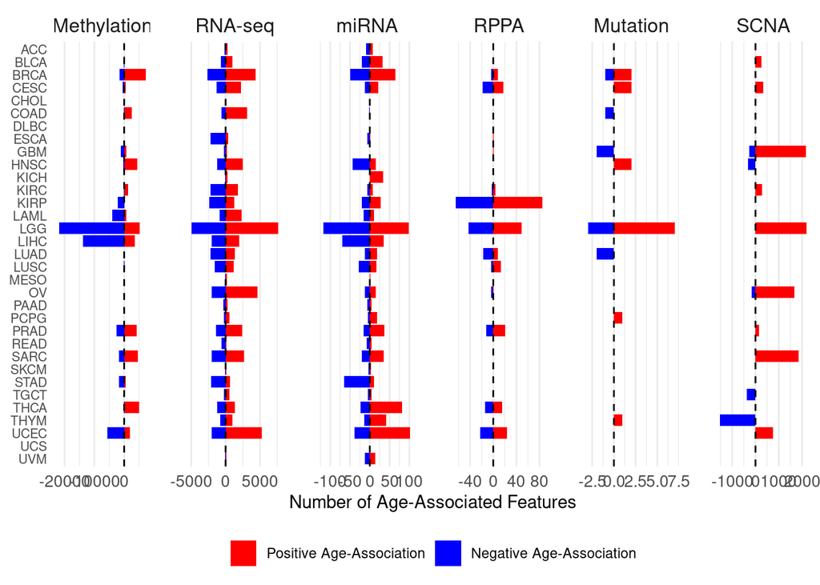

```r
fig1a_long <- part1_imported_results$fig1a_long

p_fig1A <- ggplot(fig1a_long, aes(x = Cancer, y = Count, fill = Regulation)) +
  geom_bar(stat = "identity", position = "identity") +
  scale_fill_manual(
    values = c("Positive" = "red", "Negative" = "blue"),
    labels = c(
      "Positive" = "Positive Age-Association",
      "Negative" = "Negative Age-Association"
    )
  ) +
  labs(
    x = NULL,
    y = "Number of Age-Associated Features",
    fill = NULL
  ) +
  facet_wrap(~Layer, scales = "free_x", nrow = 1) +
  coord_flip() +
  geom_hline(yintercept = 0, linetype = "dashed", color = "black") +
  theme_minimal() +
  theme(
    panel.spacing       = unit(0.8, "cm"),
    panel.grid.major.y  = element_blank(),
    panel.grid.minor.y  = element_blank(),
    axis.text.x         = element_text(size = 10),
    axis.text.y         = element_text(size = 8),
    strip.background    = element_blank(),
    strip.text.x        = element_text(size = 12),
    legend.position     = "bottom"
  )

p_fig1A
```

```r
ggsave(
  filename = file.path(fig_dir, "multiomics_age_association.pdf"),
  plot     = p_fig1A,
  width    = 7.5,
  height   = 5.25,
  units    = "in"
)

fig1a_axis_ranges <- fig1a_long %>%
  dplyr::group_by(Layer) %>%
  dplyr::summarise(
    min_count = round(min(Count, na.rm = TRUE)),
    max_count = round(max(Count, na.rm = TRUE)),
    .groups   = "drop"
  )

reactable(fig1a_axis_ranges)
```

| Layer | min_count | max_count |
| --- | --- | --- |
| Methylation | -21836 | 7236 |
| RNA-seq | -4993 | 7608 |
| miRNA | -117 | 102 |
| RPPA | -65 | 85 |
| Mutation | -3 | 7 |
| SCNA | -1517 | 2200 |

## Multi-omic similarity dendrogram

The clustering is computed in `03_prepare_clustering.Rmd` from the four retained layers (Methylation, RNA-seq, miRNA, SCNA), with a per-pair feature-overlap floor applied during cross-layer averaging. This chunk only renders the saved `hclust` object as an organ-system-annotated tree.

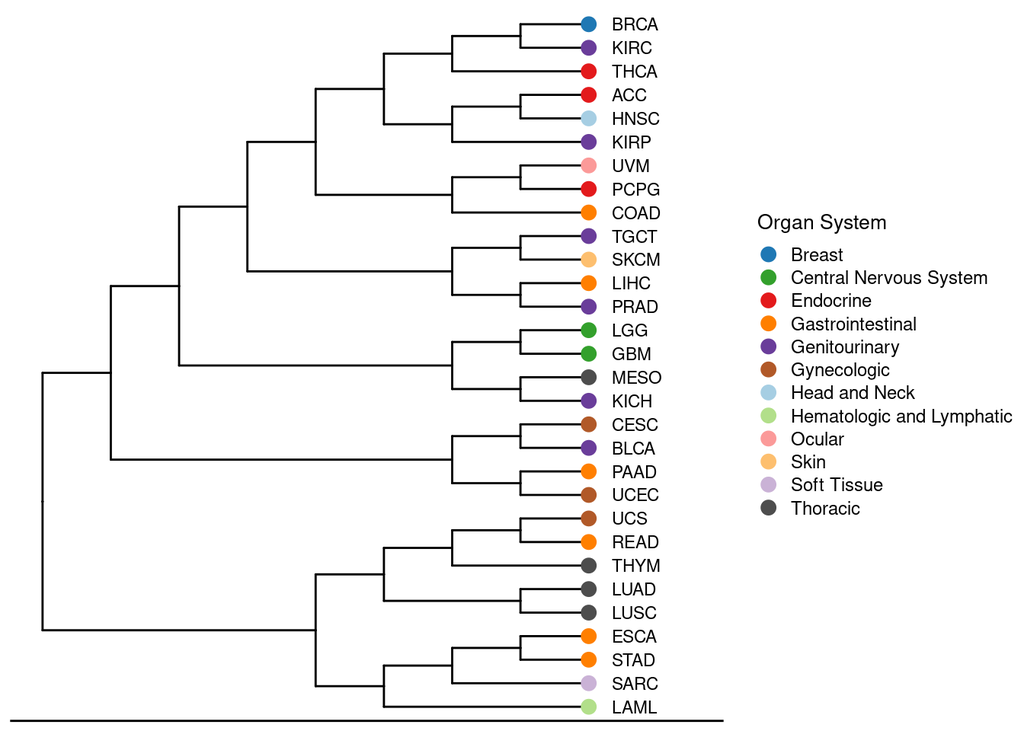

```r
hc_pw_opt <- pancancer_clustering$hclust

selected_tree_obj    <- ape::as.phylo(hc_pw_opt)
selected_orig_labels <- selected_tree_obj$tip.label
selected_clean_labels <- stringr::str_remove(selected_orig_labels, "^TCGA-")
selected_tree_obj$tip.label <- selected_clean_labels

selected_anno_df <- part1_imported_results$organ_annotations %>%
  dplyr::filter(Project %in% selected_orig_labels) %>%
  dplyr::mutate(label = stringr::str_remove(Project, "^TCGA-")) %>%
  dplyr::select(label, Organ_System)

p_fig1B <- ggtree(selected_tree_obj, layout = "rectangular", branch.length = "none") %<+% selected_anno_df +
  geom_tiplab(size = 3, align = TRUE, linetype = 0, offset = 0.3) +
  geom_tippoint(aes(color = Organ_System), size = 3) +
  scale_color_manual(
    name   = "Organ System",
    values = part1_imported_results$organ_palette
  ) +
  theme_tree2() +
  theme(
    legend.position = "right",
    plot.title      = element_blank(),
    axis.text.x     = element_blank(),
    axis.ticks.x    = element_blank(),
    plot.margin     = margin(5, 0, 5, 5),
    text            = element_text(size = 8),
    legend.text     = element_text(size = 9),
    legend.title    = element_text(size = 10),
    legend.key.size = unit(4, "mm")
  )

selected_max_x <- max(p_fig1B$data$x, na.rm = TRUE)
p_fig1B <- p_fig1B + xlim(0, selected_max_x + 1.5)

p_fig1B
```

```r
ggsave(
  filename = file.path(fig_dir, "cancer_clustering_tree.pdf"),
  plot     = p_fig1B,
  width    = 4.5,
  height   = 5,
  units    = "in"
)
```